# 成长类因子

量化投资部

## 0、加载数据

```r
#  -------single factor test step by step  -----
fls <- buildFactorLists(
  buildFactorList(factorFun = "gf.NP_YOY",
                  factorDir = 1,
                  factorPar=list(is1q=FALSE,filt=0),
                  factorName = "NP_YOY"),
  buildFactorList(factorFun = "gf.G_MLL_Q",
                  factorDir = 1,
                  factorPar=list(),
                  factorName = "G_MLL_Q"),
  buildFactorList(factorFun = "gf.G_OR_Q",
                  factorDir = 1,
                  factorPar=list(filt=0),
                  factorName = "G_OR_Q"),
  buildFactorList(factorFun = "gf.G_EPS_Q",
                  factorDir = 1,
                  factorPar=list(filt=0),
                  factorName = "G_EPS_Q"),
  buildFactorList(factorFun = "gf.G_OR_longterm",
                  factorDir = 1,
                  factorPar=list(),
                  factorName = "G_OR_longterm"),
  buildFactorList(factorFun = "gf.F_NP_chg",
                  factorDir = 1,
                  factorPar=list(con_type = "1,2"),
                  factorName = "F_NP_chg"),
  buildFactorList(factorFun = "gf.F_rank_chg",
                  factorDir = 1,
                  factorPar=list(con_type = "1,2"),
                  factorName = "F_rank_chg")
)


# time and univ setting
begT <- as.Date("2010-01-04")
endT <- as.Date("2017-11-30")
holdingEndT <- as.Date("2017-12-31")
rebFreq <- "month"
shiftby <- 0
univ <- "EI000985"

# getTSR
rebdate <- getRebDates(begT,endT,rebFreq,shiftby)
ts <- getTS(rebdate,indexID = univ,rm="suspend")
tsr <- getTSR(ts,date_end_pad = holdingEndT)


# raw factor descrptive statistics
tsfr_raw <- getMultiFactor(tsr,FactorList = fls)
tsfrs_raw <- mTSF2TSFs(tsfr_raw)
fnames <- names(tsfrs_raw)

# table.Fct_descr(tsfr_raw,9)
# sectorAttrs <- list(ind=defaultSectorAttr("ind"),
#                     fct=defaultSectorAttr("fct"),
#                     ind_fct=defaultSectorAttr("ind_fct"))
# chart.Fct_anova(tsfr_raw,sectorAttrs)

# factor refine research
refinePars <- list(scale = refinePar_default("scale",NULL),
                   scale_ind = refinePar_default("scale",defaultSectorAttr("ind")),
                   scale_indfct= refinePar_default("scale",defaultSectorAttr("ind_fct")),
                   reg_indfct = refinePar_default("reg",defaultSectorAttr("ind")))
tablestats <- data.frame()
mtsfrrefine <- data.frame()
tablenames <- c("IC_mean","IC_IR","IC_hitRatio","Annualized Return",
                 "Annualized Sharpe(Rf=0%)","Worst Drawdown","Beta","Size")
```

## 1、因子NP_YOY

```r
fname_ <- fnames[1]
tsfr <- tsfrs_raw[[fname_]]
mtsfr <- factor_refine_MF(tsfr,refinePars)
```

```
## Function getTSF: getting the factorscore ....
## Function getTSF: getting the factorscore ....
```

```r
mtsfrrefine <- rbind(mtsfrrefine,data.frame(mtsfr,fname=fname_))
```

因子NA比例

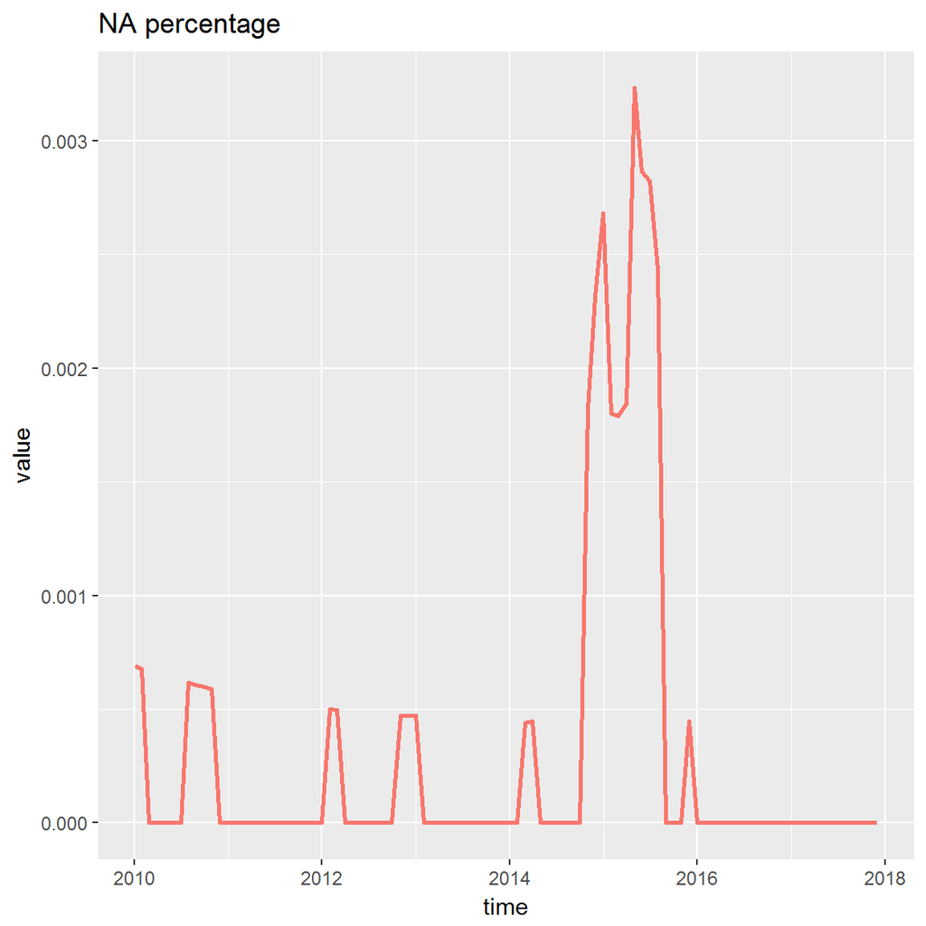

```r
chart.Fct_NA(tsfr)
```

因子原始得分直方图

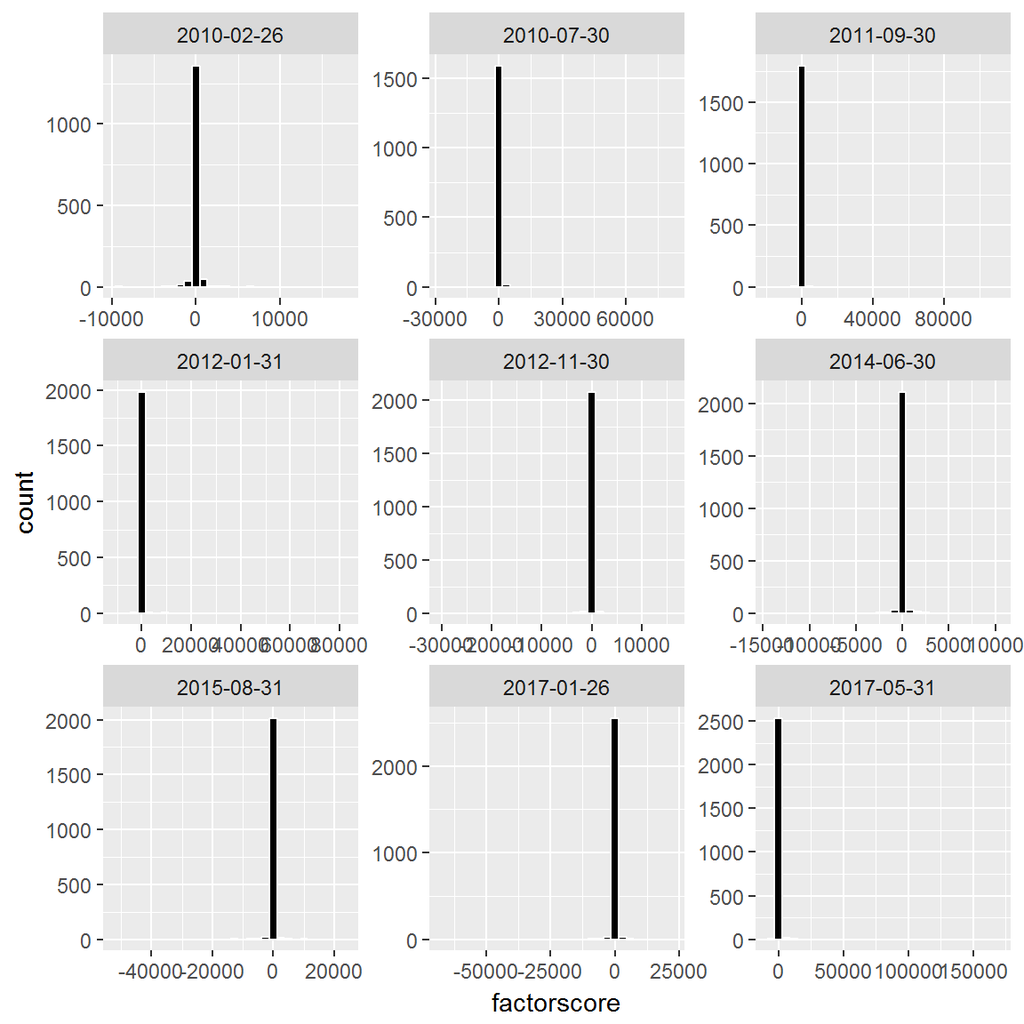

```r
chart.Fct_hist(tsfr,9)
```

不同refine方式下因子得分分布直方图

```
## The guessed factorNames are: scale,scale_ind,scale_indfct,reg_indfct.
```

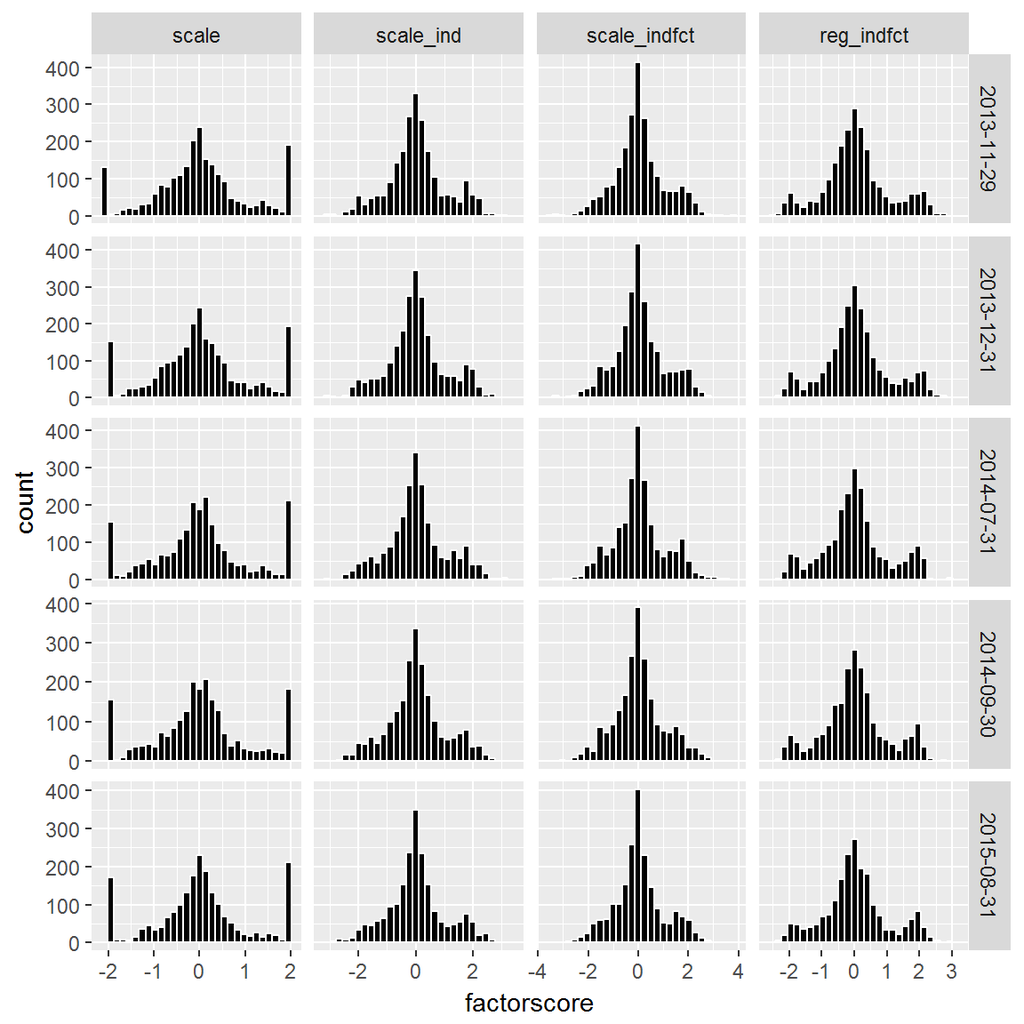

```r
MF.chart.Fct_hist(mtsfr,5)
```

不同refine方式下因子得分统计表

```r
kable(MF.table.Fct_descr(mtsfr,5),digits = 2)
```

```
## The guessed factorNames are: scale,scale_ind,scale_indfct,reg_indfct.
```

| date | fname | Obs | NAs | min | max | mean | median | sd | skewness | kurtosis |
| --- | --- | --- | --- | --- | --- | --- | --- | --- | --- | --- |
| 2014-03-31 | scale | 2244 | 0 | -1.96 | 1.91 | 0.02 | 0 | 1.00 | 0.03 | -0.16 |
| 2014-03-31 | scale_ind | 2244 | 0 | -2.71 | 2.83 | 0.04 | 0 | 1.00 | 0.09 | 0.03 |
| 2014-03-31 | scale_indfct | 2244 | 0 | -3.29 | 3.36 | 0.05 | 0 | 0.99 | 0.18 | 0.16 |
| 2014-03-31 | reg_indfct | 2244 | 0 | -2.46 | 2.63 | 0.06 | 0 | 1.00 | 0.16 | -0.07 |
| 2014-07-31 | scale | 2224 | 0 | -1.92 | 1.89 | 0.01 | 0 | 1.00 | 0.08 | -0.19 |
| 2014-07-31 | scale_ind | 2224 | 0 | -3.08 | 2.99 | 0.04 | 0 | 1.00 | 0.14 | 0.09 |
| 2014-07-31 | scale_indfct | 2224 | 0 | -3.22 | 3.44 | 0.05 | 0 | 0.99 | 0.22 | 0.21 |
| 2014-07-31 | reg_indfct | 2224 | 0 | -2.32 | 2.94 | 0.04 | 0 | 1.00 | 0.16 | -0.06 |
| 2014-10-31 | scale | 2196 | 0 | -2.00 | 1.95 | -0.01 | 0 | 1.00 | 0.04 | -0.07 |
| 2014-10-31 | scale_ind | 2196 | 0 | -2.59 | 2.94 | 0.01 | 0 | 1.00 | 0.12 | 0.24 |
| 2014-10-31 | scale_indfct | 2196 | 0 | -3.07 | 3.04 | 0.02 | 0 | 0.99 | 0.15 | 0.31 |
| 2014-10-31 | reg_indfct | 2196 | 0 | -2.45 | 2.91 | 0.02 | 0 | 1.00 | 0.14 | 0.06 |
| 2015-11-30 | scale | 2245 | 0 | -1.89 | 1.90 | 0.00 | 0 | 1.00 | 0.04 | -0.17 |
| 2015-11-30 | scale_ind | 2245 | 0 | -3.44 | 3.16 | 0.01 | 0 | 1.00 | 0.12 | 0.28 |
| 2015-11-30 | scale_indfct | 2245 | 0 | -3.59 | 3.55 | 0.03 | 0 | 1.00 | 0.17 | 0.32 |
| 2015-11-30 | reg_indfct | 2245 | 0 | -2.49 | 3.19 | 0.04 | 0 | 1.00 | 0.19 | 0.07 |
| 2016-05-31 | scale | 2433 | 0 | -1.86 | 1.94 | 0.09 | 0 | 1.00 | 0.20 | -0.21 |
| 2016-05-31 | scale_ind | 2433 | 0 | -2.76 | 3.64 | 0.10 | 0 | 1.00 | 0.29 | 0.19 |
| 2016-05-31 | scale_indfct | 2433 | 0 | -3.02 | 3.64 | 0.11 | 0 | 1.00 | 0.28 | 0.25 |
| 2016-05-31 | reg_indfct | 2433 | 0 | -2.19 | 2.79 | 0.10 | 0 | 1.00 | 0.22 | -0.12 |

不同refine方式下因子IC图

```
## The guessed factorNames are: scale,scale_ind,scale_indfct,reg_indfct.
```

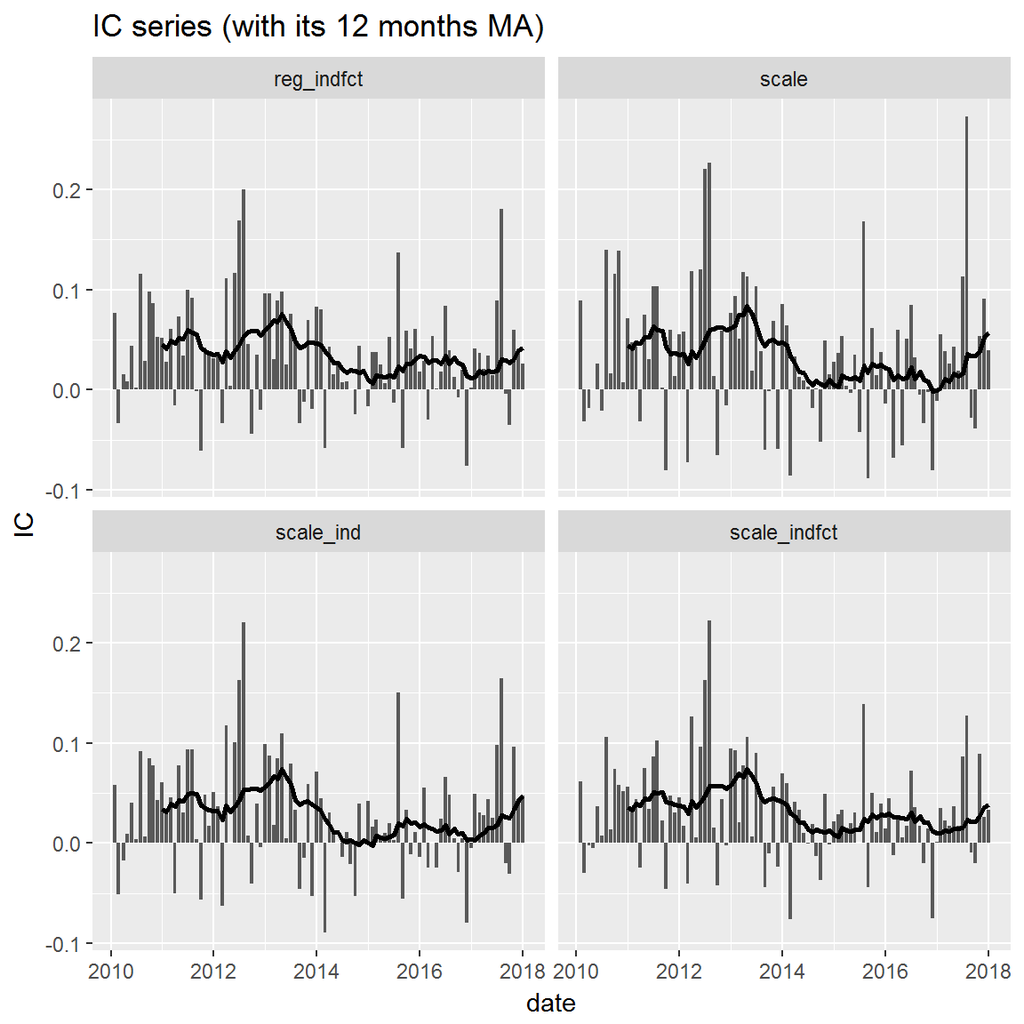

```r
MF.chart.IC(mTSFR = mtsfr,facet_by = 'fname')
```

不同refine方式下因子分组多空收益图

```
## The guessed factorNames are: scale,scale_ind,scale_indfct,reg_indfct.
```

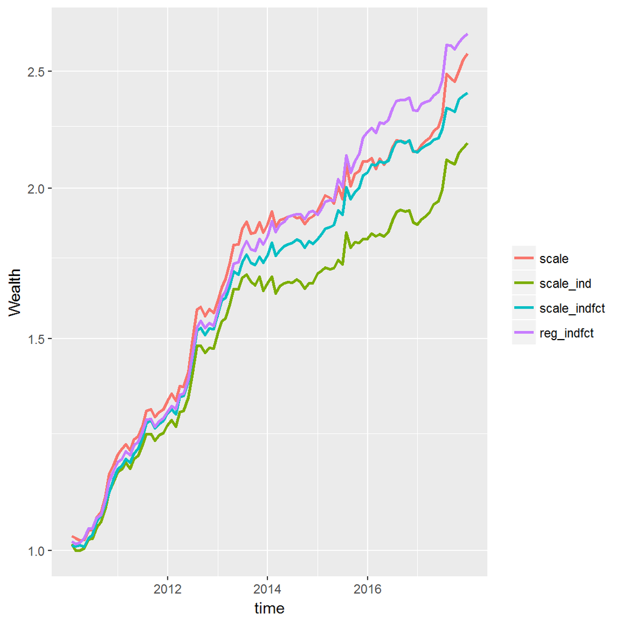

```r
MF.chart.Ngroup.spread(mTSFR = mtsfr, N = 5)
```

不同refine方式下因子分组多空相对收益图

```
## The guessed factorNames are: scale,scale_ind,scale_indfct,reg_indfct.
```

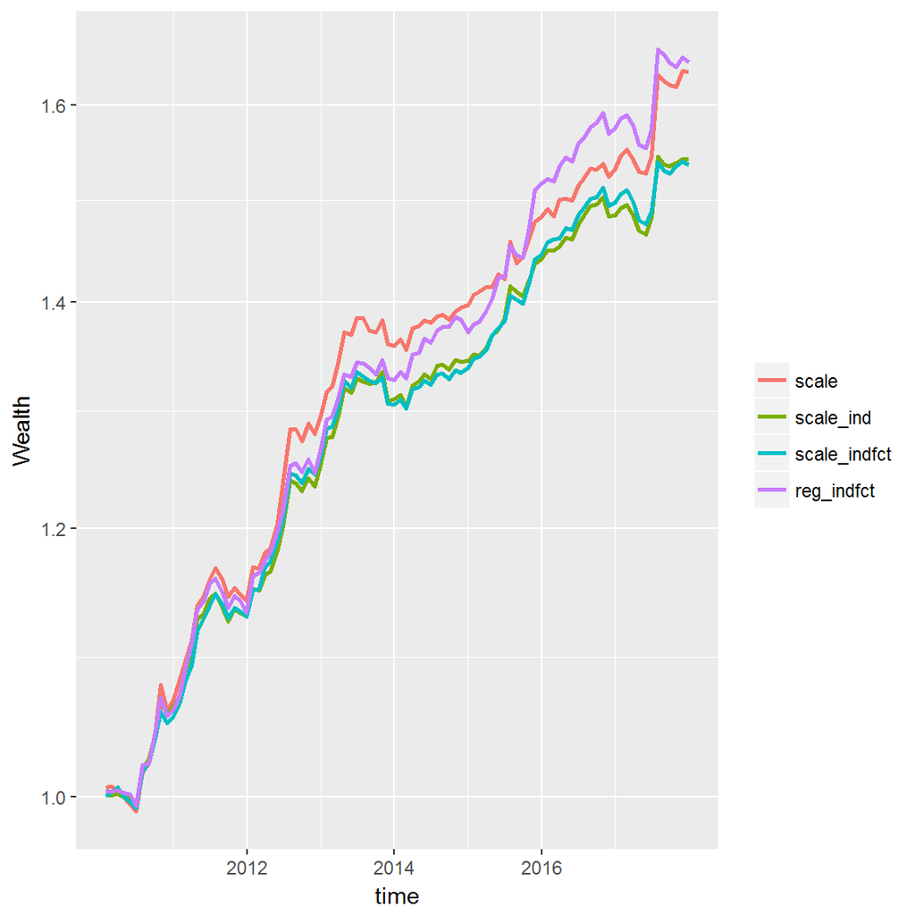

```r
MF.chart.Ngroup.spread(mTSFR = mtsfr, N = 5,rtn_type = "long-univ")
```

不同refine方式下因子IC和分组收益统计表

```r
table_ <- MC.table.ICandNgroup(mTSF2TSFs(mtsfr), N = 5)
```

```
## The guessed factorNames are: scale,scale_ind,scale_indfct,reg_indfct.
```

```r
table_ <- table_[,tablenames]
kable(table_,digits = 2)
```

|  | IC_mean | IC_IR | IC_hitRatio | Annualized Return | Annualized Sharpe(Rf=0%) | Worst Drawdown | Beta | Size |
| --- | --- | --- | --- | --- | --- | --- | --- | --- |
| scale | 0.03 | 0.50 | 0.72 | 0.13 | 1.84 | 0.04 | -0.03 | 27.29 |
| scale_ind | 0.03 | 0.52 | 0.74 | 0.10 | 1.80 | 0.04 | -0.04 | -13.42 |
| scale_indfct | 0.03 | 0.65 | 0.77 | 0.12 | 2.25 | 0.02 | -0.02 | -25.84 |
| reg_indfct | 0.04 | 0.69 | 0.79 | 0.13 | 2.24 | 0.03 | 0.00 | -33.09 |

```r
table_ <- data.frame(factorName=fname_,refinePar=rownames(table_),table_,row.names = NULL,stringsAsFactors = FALSE)
tablestats <- rbind(tablestats,table_)
```

## 2、因子G_MLL_Q

```r
fname_ <- fnames[2]
tsfr <- tsfrs_raw[[fname_]]
mtsfr <- factor_refine_MF(tsfr,refinePars)
```

```
## Function getTSF: getting the factorscore ....
## Function getTSF: getting the factorscore ....
```

```r
mtsfrrefine <- rbind(mtsfrrefine,data.frame(mtsfr,fname=fname_))
```

```r
chart.Fct_NA(tsfr)
```

[output not shown]

因子原始得分直方图

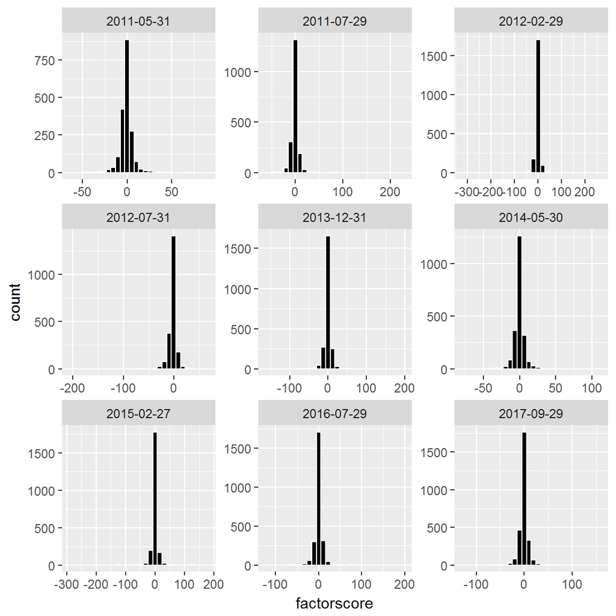

```r
chart.Fct_hist(tsfr,9)
```

不同refine方式下因子得分分布直方图

```
## The guessed factorNames are: scale,scale_ind,scale_indfct,reg_indfct.
```

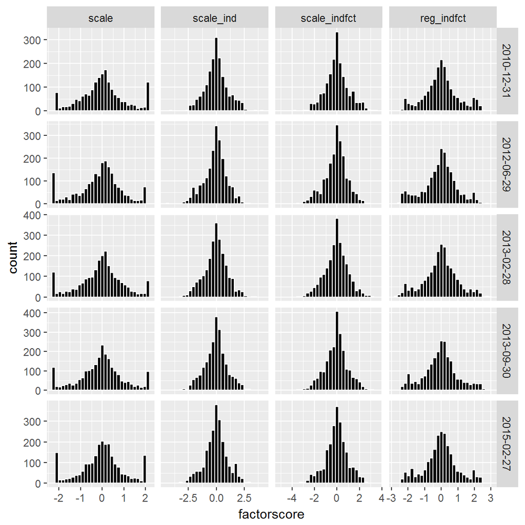

```r
MF.chart.Fct_hist(mtsfr,5)
```

不同refine方式下因子得分统计表

```r
kable(MF.table.Fct_descr(mtsfr,5),digits = 2)
```

```
## The guessed factorNames are: scale,scale_ind,scale_indfct,reg_indfct.
```

| date | fname | Obs | NAs | min | max | mean | median | sd | skewness | kurtosis |
| --- | --- | --- | --- | --- | --- | --- | --- | --- | --- | --- |
| 2010-08-31 | scale | 1646 | 0 | -2.10 | 2.07 | 0.01 | 0 | 1.00 | 0.07 | 0.03 |
| 2010-08-31 | scale_ind | 1646 | 0 | -3.30 | 3.41 | 0.02 | 0 | 1.00 | 0.13 | 0.27 |
| 2010-08-31 | scale_indfct | 1646 | 0 | -3.08 | 3.98 | 0.02 | 0 | 0.99 | 0.16 | 0.27 |
| 2010-08-31 | reg_indfct | 1646 | 0 | -2.48 | 2.58 | 0.02 | 0 | 1.00 | 0.07 | 0.11 |
| 2010-12-31 | scale | 1765 | 0 | -2.12 | 2.07 | 0.01 | 0 | 1.00 | 0.11 | 0.04 |
| 2010-12-31 | scale_ind | 1765 | 0 | -3.96 | 3.95 | 0.02 | 0 | 0.99 | 0.17 | 0.43 |
| 2010-12-31 | scale_indfct | 1765 | 0 | -3.68 | 3.45 | 0.01 | 0 | 0.99 | 0.13 | 0.33 |
| 2010-12-31 | reg_indfct | 1765 | 0 | -2.40 | 2.58 | 0.01 | 0 | 1.00 | 0.11 | 0.15 |
| 2013-04-26 | scale | 2232 | 0 | -2.10 | 2.03 | -0.05 | 0 | 1.00 | -0.13 | 0.02 |
| 2013-04-26 | scale_ind | 2232 | 0 | -3.09 | 3.18 | -0.03 | 0 | 1.00 | -0.09 | 0.28 |
| 2013-04-26 | scale_indfct | 2232 | 0 | -3.02 | 3.87 | -0.04 | 0 | 0.99 | -0.06 | 0.28 |
| 2013-04-26 | reg_indfct | 2232 | 0 | -2.48 | 2.76 | -0.03 | 0 | 1.00 | -0.06 | 0.09 |
| 2014-06-30 | scale | 2227 | 0 | -2.13 | 2.08 | -0.03 | 0 | 1.00 | -0.06 | 0.10 |
| 2014-06-30 | scale_ind | 2227 | 0 | -3.76 | 3.60 | -0.01 | 0 | 1.00 | -0.03 | 0.46 |
| 2014-06-30 | scale_indfct | 2227 | 0 | -4.01 | 4.36 | -0.01 | 0 | 0.99 | -0.03 | 0.60 |
| 2014-06-30 | reg_indfct | 2227 | 0 | -2.55 | 2.63 | 0.00 | 0 | 1.00 | 0.04 | 0.15 |
| 2014-09-30 | scale | 2204 | 0 | -2.14 | 2.05 | -0.04 | 0 | 1.00 | -0.11 | 0.07 |
| 2014-09-30 | scale_ind | 2204 | 0 | -3.32 | 3.68 | -0.02 | 0 | 1.00 | -0.08 | 0.43 |
| 2014-09-30 | scale_indfct | 2204 | 0 | -3.54 | 3.09 | -0.02 | 0 | 0.99 | -0.12 | 0.34 |
| 2014-09-30 | reg_indfct | 2204 | 0 | -2.81 | 2.72 | -0.02 | 0 | 1.00 | -0.02 | 0.19 |

不同refine方式下因子IC图

```
## The guessed factorNames are: scale,scale_ind,scale_indfct,reg_indfct.
```

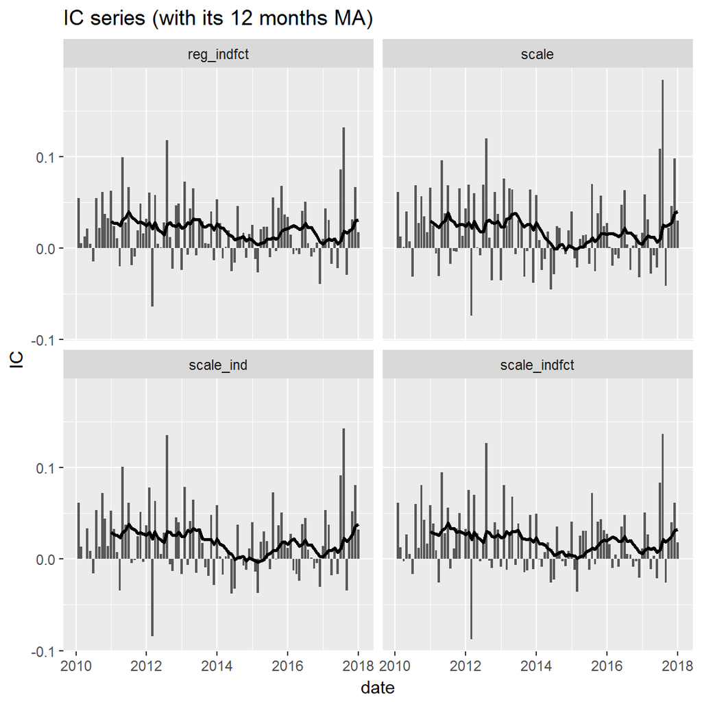

```r
MF.chart.IC(mTSFR = mtsfr,facet_by = 'fname')
```

不同refine方式下因子分组多空收益图

```
## The guessed factorNames are: scale,scale_ind,scale_indfct,reg_indfct.
```

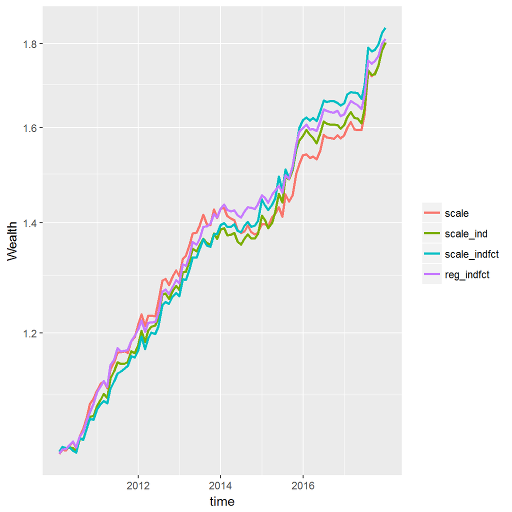

```r
MF.chart.Ngroup.spread(mTSFR = mtsfr, N = 5)
```

不同refine方式下因子分组多空相对收益图

```
## The guessed factorNames are: scale,scale_ind,scale_indfct,reg_indfct.
```

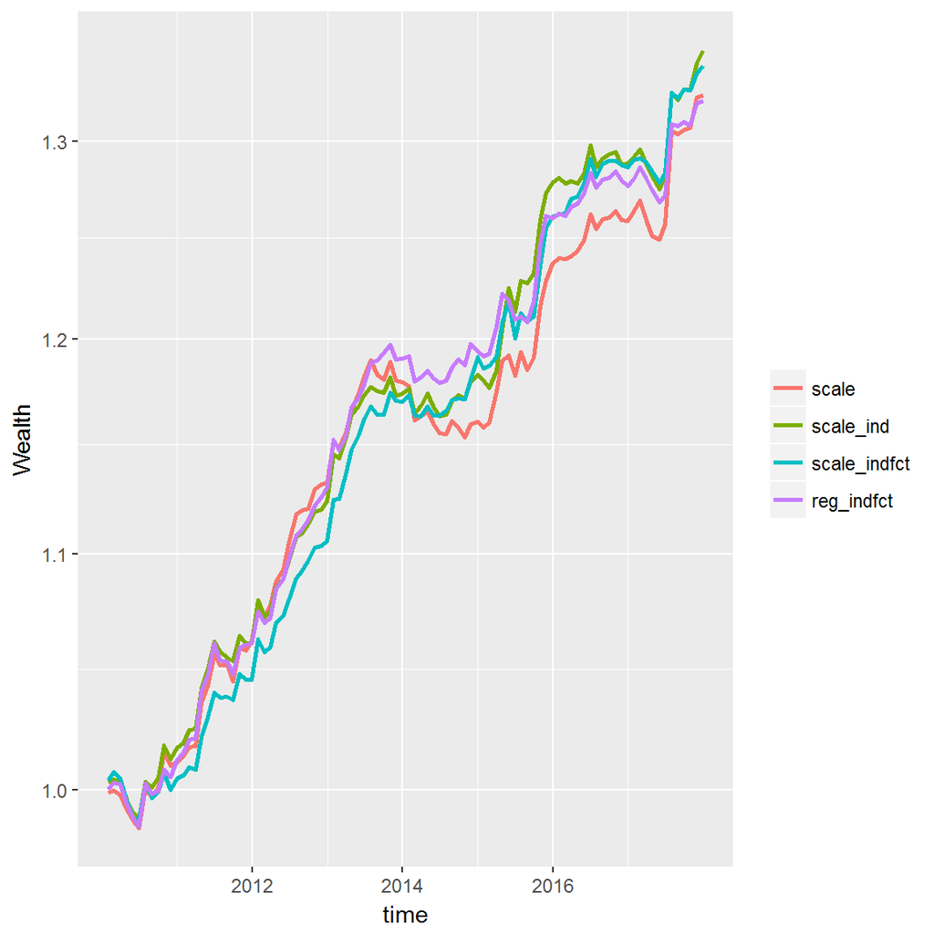

```r
MF.chart.Ngroup.spread(mTSFR = mtsfr, N = 5,rtn_type = "long-univ")
```

不同refine方式下因子IC和分组收益统计表

```r
table_ <- MC.table.ICandNgroup(mTSF2TSFs(mtsfr), N = 5)
```

```
## The guessed factorNames are: scale,scale_ind,scale_indfct,reg_indfct.
```

```r
table_ <- table_[,tablenames]
kable(table_,digits = 2)
```

|  | IC_mean | IC_IR | IC_hitRatio | Annualized Return | Annualized Sharpe(Rf=0%) | Worst Drawdown | Beta | Size |
| --- | --- | --- | --- | --- | --- | --- | --- | --- |
| scale | 0.02 | 0.50 | 0.66 | 0.08 | 1.80 | 0.04 | -0.01 | 5.15 |
| scale_ind | 0.02 | 0.52 | 0.65 | 0.08 | 1.84 | 0.02 | -0.01 | 26.80 |
| scale_indfct | 0.02 | 0.59 | 0.66 | 0.08 | 1.96 | 0.02 | 0.00 | 18.84 |
| reg_indfct | 0.02 | 0.63 | 0.72 | 0.08 | 2.11 | 0.02 | -0.01 | -7.78 |

```r
table_ <- data.frame(factorName=fname_,refinePar=rownames(table_),table_,row.names = NULL,stringsAsFactors = FALSE)
tablestats <- rbind(tablestats,table_)
```

## 3、因子G_OR_Q

```r
fname_ <- fnames[3]
tsfr <- tsfrs_raw[[fname_]]
mtsfr <- factor_refine_MF(tsfr,refinePars)
```

```
## Function getTSF: getting the factorscore ....
## Function getTSF: getting the factorscore ....
```

```r
mtsfrrefine <- rbind(mtsfrrefine,data.frame(mtsfr,fname=fname_))
```

```r
chart.Fct_NA(tsfr)
```

[output not shown]

因子原始得分直方图

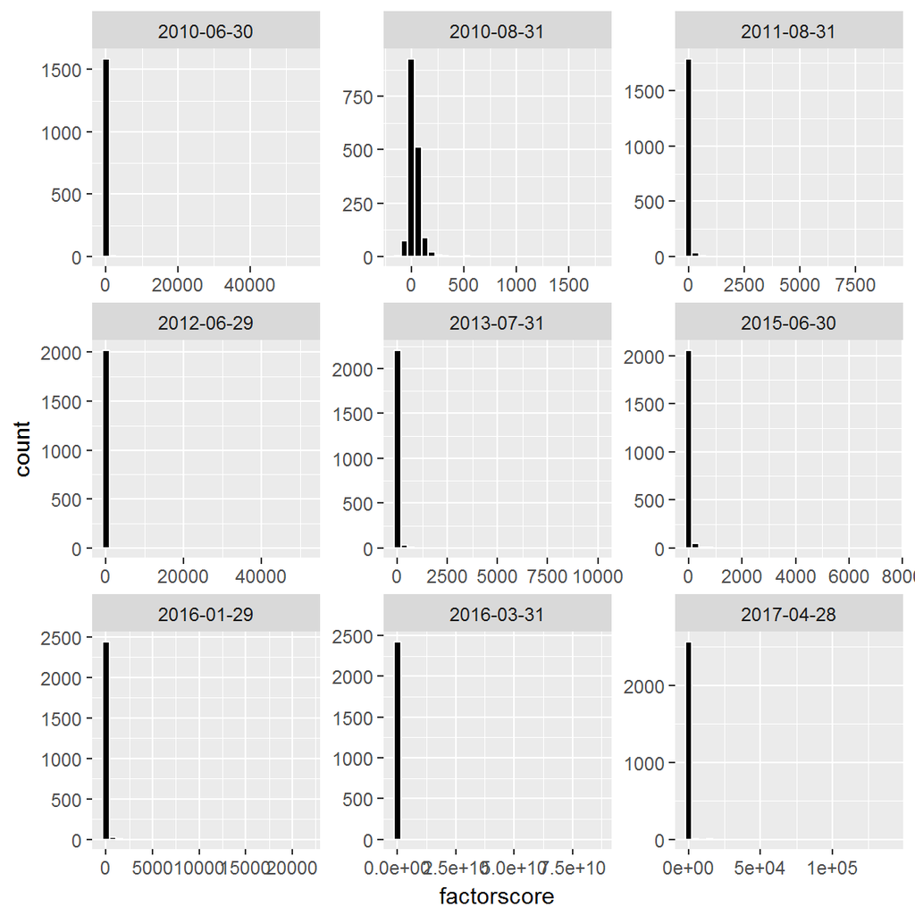

```r
chart.Fct_hist(tsfr,9)
```

不同refine方式下因子得分分布直方图

```
## The guessed factorNames are: scale,scale_ind,scale_indfct,reg_indfct.
```

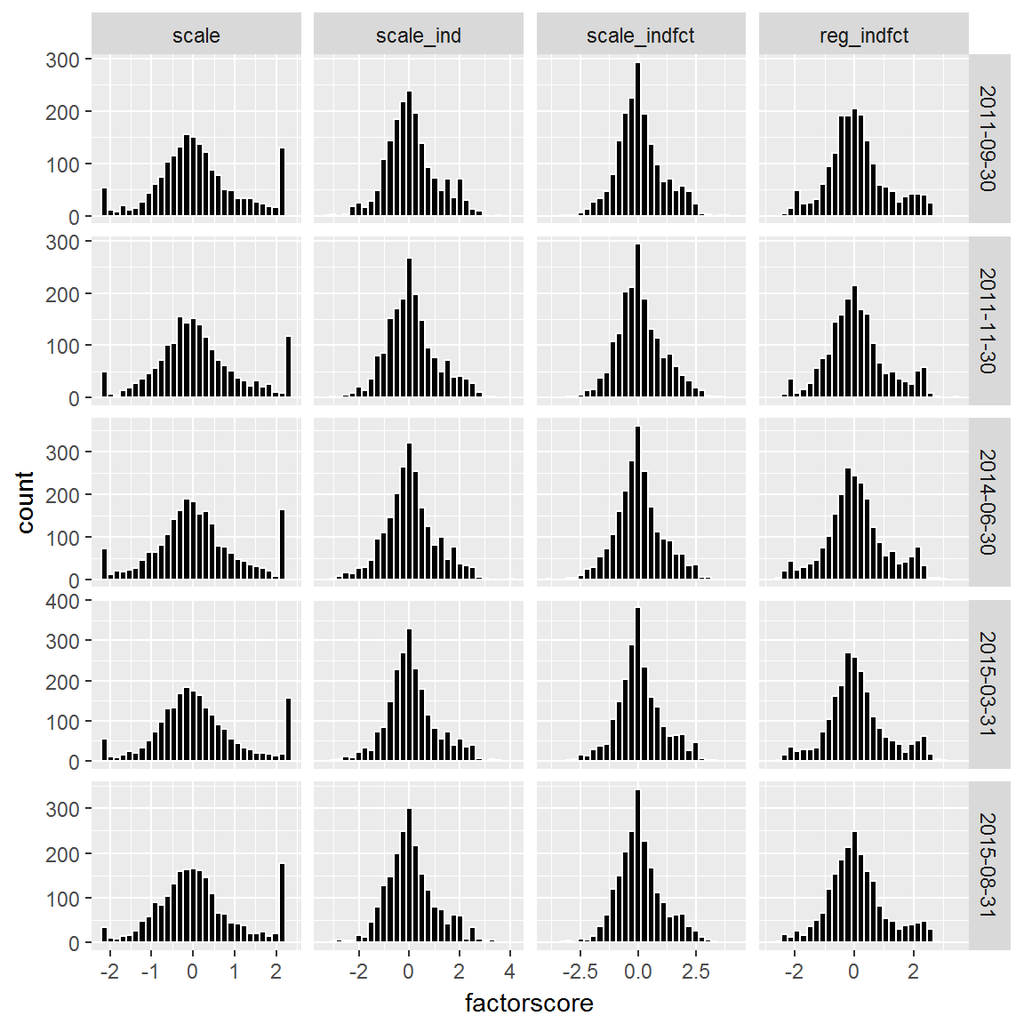

```r
MF.chart.Fct_hist(mtsfr,5)
```

不同refine方式下因子得分统计表

```r
kable(MF.table.Fct_descr(mtsfr,5),digits = 2)
```

```
## The guessed factorNames are: scale,scale_ind,scale_indfct,reg_indfct.
```

| date | fname | Obs | NAs | min | max | mean | median | sd | skewness | kurtosis |
| --- | --- | --- | --- | --- | --- | --- | --- | --- | --- | --- |
| 2010-07-30 | scale | 1617 | 0 | -2.13 | 2.41 | 0.20 | 0 | 0.99 | 0.58 | 0.26 |
| 2010-07-30 | scale_ind | 1617 | 0 | -2.78 | 4.28 | 0.14 | 0 | 0.99 | 0.58 | 0.93 |
| 2010-07-30 | scale_indfct | 1617 | 0 | -3.03 | 4.28 | 0.13 | 0 | 0.99 | 0.53 | 0.81 |
| 2010-07-30 | reg_indfct | 1617 | 0 | -2.79 | 3.07 | 0.13 | 0 | 0.99 | 0.38 | 0.58 |
| 2012-08-31 | scale | 2120 | 0 | -2.18 | 2.26 | 0.08 | 0 | 1.00 | 0.33 | 0.10 |
| 2012-08-31 | scale_ind | 2120 | 0 | -3.07 | 3.15 | 0.07 | 0 | 1.00 | 0.37 | 0.42 |
| 2012-08-31 | scale_indfct | 2120 | 0 | -3.07 | 4.13 | 0.06 | 0 | 1.00 | 0.35 | 0.43 |
| 2012-08-31 | reg_indfct | 2120 | 0 | -2.48 | 2.71 | 0.07 | 0 | 1.00 | 0.30 | 0.21 |
| 2015-10-30 | scale | 2160 | 0 | -2.15 | 2.22 | 0.11 | 0 | 1.00 | 0.41 | 0.08 |
| 2015-10-30 | scale_ind | 2160 | 0 | -3.03 | 3.32 | 0.10 | 0 | 1.00 | 0.46 | 0.53 |
| 2015-10-30 | scale_indfct | 2160 | 0 | -3.05 | 3.60 | 0.11 | 0 | 0.99 | 0.45 | 0.52 |
| 2015-10-30 | reg_indfct | 2160 | 0 | -2.94 | 3.19 | 0.11 | 0 | 1.00 | 0.40 | 0.36 |
| 2017-04-28 | scale | 2572 | 0 | -2.02 | 2.22 | 0.17 | 0 | 1.00 | 0.41 | -0.01 |
| 2017-04-28 | scale_ind | 2572 | 0 | -2.82 | 3.42 | 0.13 | 0 | 1.00 | 0.47 | 0.47 |
| 2017-04-28 | scale_indfct | 2572 | 0 | -3.46 | 3.98 | 0.13 | 0 | 0.99 | 0.45 | 0.59 |
| 2017-04-28 | reg_indfct | 2572 | 0 | -2.67 | 2.86 | 0.14 | 0 | 1.00 | 0.42 | 0.24 |
| 2017-06-30 | scale | 2739 | 0 | -2.08 | 2.29 | 0.16 | 0 | 1.00 | 0.45 | 0.06 |
| 2017-06-30 | scale_ind | 2739 | 0 | -2.98 | 3.30 | 0.15 | 0 | 1.00 | 0.52 | 0.54 |
| 2017-06-30 | scale_indfct | 2739 | 0 | -3.21 | 3.59 | 0.14 | 0 | 1.00 | 0.47 | 0.51 |
| 2017-06-30 | reg_indfct | 2739 | 0 | -3.13 | 2.86 | 0.15 | 0 | 1.00 | 0.48 | 0.37 |

不同refine方式下因子IC图

```
## The guessed factorNames are: scale,scale_ind,scale_indfct,reg_indfct.
```

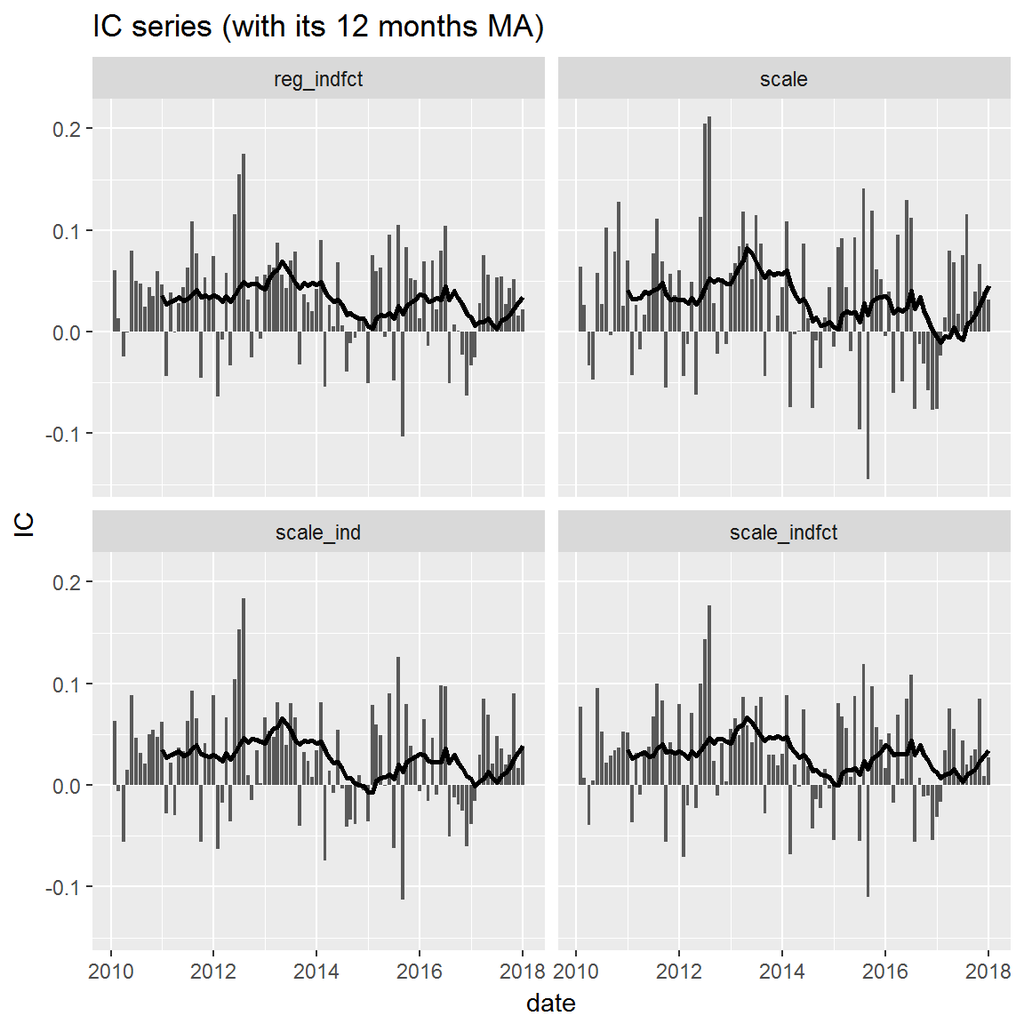

```r
MF.chart.IC(mTSFR = mtsfr,facet_by = 'fname')
```

不同refine方式下因子分组多空收益图

```
## The guessed factorNames are: scale,scale_ind,scale_indfct,reg_indfct.
```

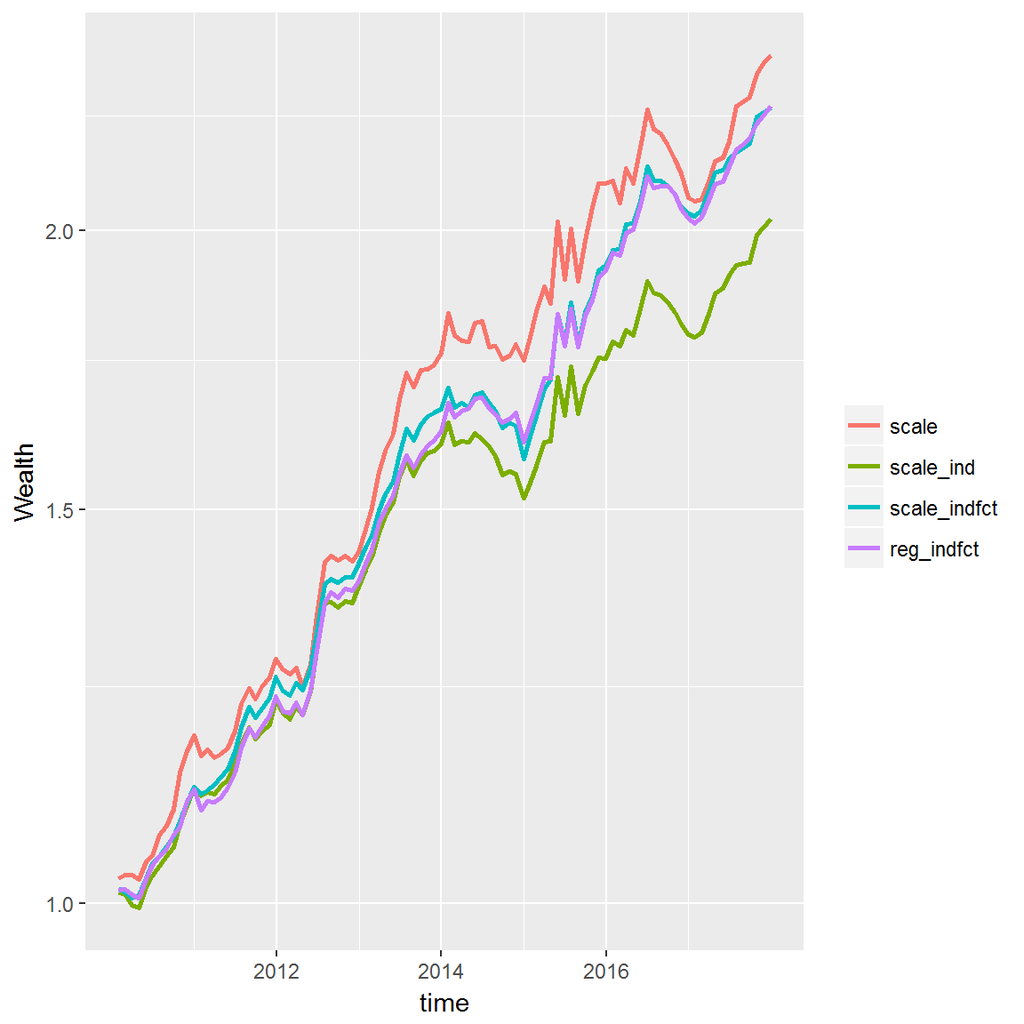

```r
MF.chart.Ngroup.spread(mTSFR = mtsfr, N = 5)
```

不同refine方式下因子分组多空相对收益图

```
## The guessed factorNames are: scale,scale_ind,scale_indfct,reg_indfct.
```

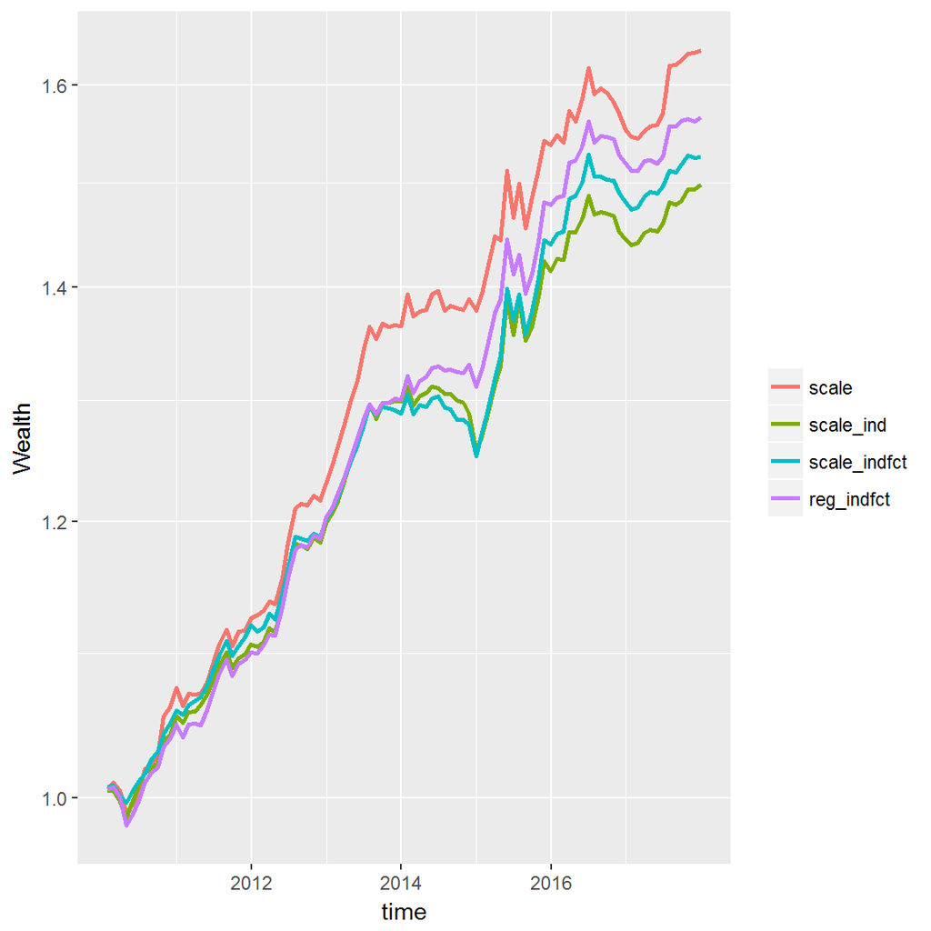

```r
MF.chart.Ngroup.spread(mTSFR = mtsfr, N = 5,rtn_type = "long-univ")
```

不同refine方式下因子IC和分组收益统计表

```r
table_ <- MC.table.ICandNgroup(mTSF2TSFs(mtsfr), N = 5)
```

```
## The guessed factorNames are: scale,scale_ind,scale_indfct,reg_indfct.
```

```r
table_ <- table_[,tablenames]
kable(table_,digits = 2)
```

|  | IC_mean | IC_IR | IC_hitRatio | Annualized Return | Annualized Sharpe(Rf=0%) | Worst Drawdown | Beta | Size |
| --- | --- | --- | --- | --- | --- | --- | --- | --- |
| scale | 0.03 | 0.49 | 0.68 | 0.12 | 1.47 | 0.09 | 0.04 | 28.42 |
| scale_ind | 0.03 | 0.52 | 0.68 | 0.09 | 1.52 | 0.07 | 0.01 | -20.79 |
| scale_indfct | 0.03 | 0.60 | 0.74 | 0.11 | 1.83 | 0.07 | 0.02 | -33.57 |
| reg_indfct | 0.03 | 0.64 | 0.74 | 0.11 | 1.89 | 0.05 | 0.02 | -30.47 |

```r
table_ <- data.frame(factorName=fname_,refinePar=rownames(table_),table_,row.names = NULL,stringsAsFactors = FALSE)
tablestats <- rbind(tablestats,table_)
```

## 4、因子G_EPS_Q

```r
fname_ <- fnames[4]
tsfr <- tsfrs_raw[[fname_]]
mtsfr <- factor_refine_MF(tsfr,refinePars)
```

```
## Function getTSF: getting the factorscore ....
## Function getTSF: getting the factorscore ....
```

```r
mtsfrrefine <- rbind(mtsfrrefine,data.frame(mtsfr,fname=fname_))
```

```r
chart.Fct_NA(tsfr)
```

[output not shown]

因子原始得分直方图

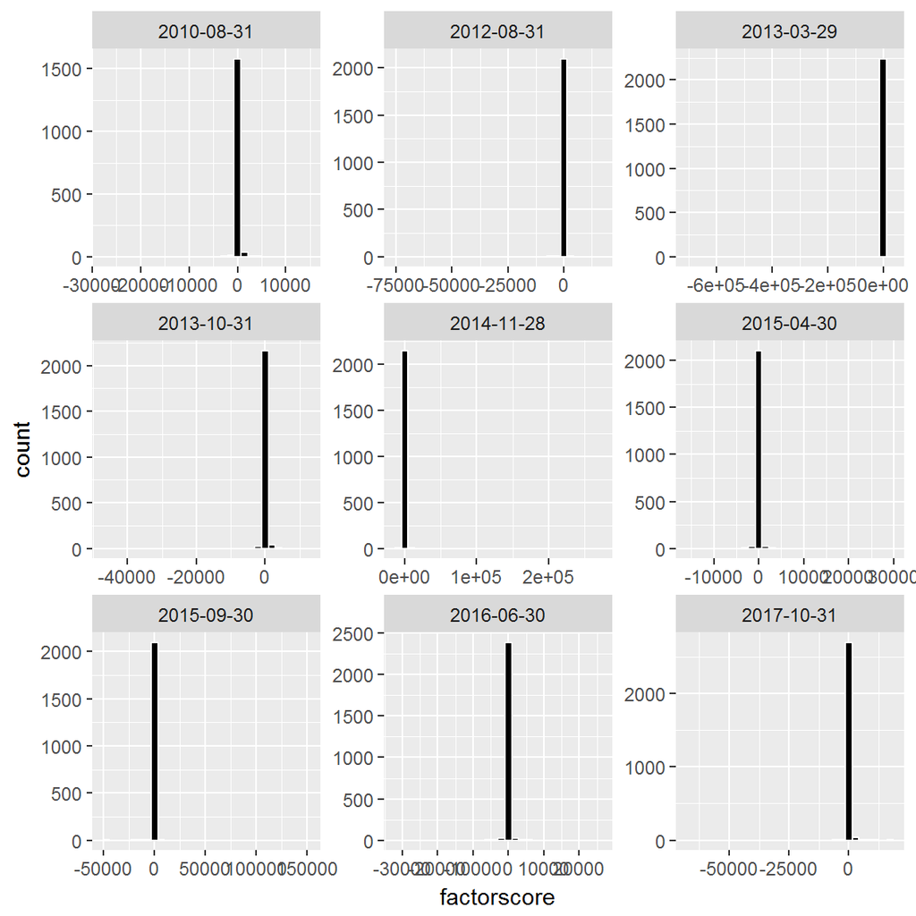

```r
chart.Fct_hist(tsfr,9)
```

不同refine方式下因子得分分布直方图

```
## The guessed factorNames are: scale,scale_ind,scale_indfct,reg_indfct.
```

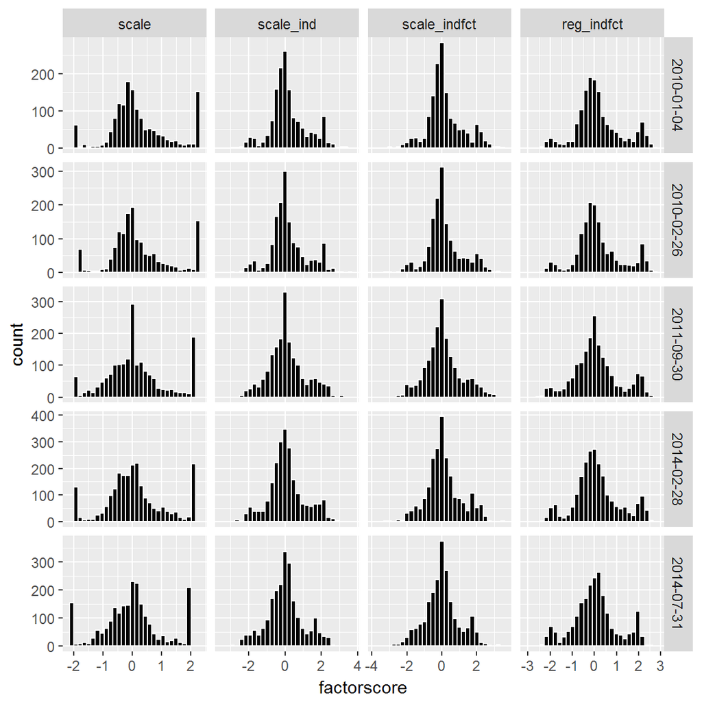

```r
MF.chart.Fct_hist(mtsfr,5)
```

不同refine方式下因子得分统计表

```r
kable(MF.table.Fct_descr(mtsfr,5),digits = 2)
```

```
## The guessed factorNames are: scale,scale_ind,scale_indfct,reg_indfct.
```

| date | fname | Obs | NAs | min | max | mean | median | sd | skewness | kurtosis |
| --- | --- | --- | --- | --- | --- | --- | --- | --- | --- | --- |
| 2013-12-31 | scale | 2301 | 0 | -1.92 | 2.04 | 0.08 | 0 | 1.00 | 0.23 | -0.03 |
| 2013-12-31 | scale_ind | 2301 | 0 | -3.30 | 2.84 | 0.09 | 0 | 1.00 | 0.25 | 0.25 |
| 2013-12-31 | scale_indfct | 2301 | 0 | -3.30 | 3.50 | 0.11 | 0 | 0.99 | 0.27 | 0.35 |
| 2013-12-31 | reg_indfct | 2301 | 0 | -2.95 | 2.57 | 0.11 | 0 | 1.00 | 0.30 | 0.12 |
| 2014-02-28 | scale | 2281 | 0 | -1.97 | 2.04 | 0.09 | 0 | 1.00 | 0.22 | 0.01 |
| 2014-02-28 | scale_ind | 2281 | 0 | -3.34 | 3.26 | 0.09 | 0 | 1.00 | 0.25 | 0.31 |
| 2014-02-28 | scale_indfct | 2281 | 0 | -3.34 | 3.52 | 0.11 | 0 | 0.99 | 0.27 | 0.37 |
| 2014-02-28 | reg_indfct | 2281 | 0 | -3.03 | 2.54 | 0.11 | 0 | 1.00 | 0.28 | 0.17 |
| 2015-12-31 | scale | 2477 | 0 | -2.02 | 1.84 | -0.06 | 0 | 1.00 | -0.02 | -0.08 |
| 2015-12-31 | scale_ind | 2477 | 0 | -2.94 | 3.01 | 0.00 | 0 | 1.00 | 0.05 | 0.16 |
| 2015-12-31 | scale_indfct | 2477 | 0 | -3.55 | 3.04 | 0.00 | 0 | 1.00 | 0.06 | 0.24 |
| 2015-12-31 | reg_indfct | 2477 | 0 | -2.26 | 3.04 | 0.01 | 0 | 1.00 | 0.09 | 0.04 |
| 2017-04-28 | scale | 2572 | 0 | -1.93 | 2.09 | 0.15 | 0 | 1.00 | 0.34 | -0.01 |
| 2017-04-28 | scale_ind | 2572 | 0 | -2.80 | 3.16 | 0.10 | 0 | 1.00 | 0.30 | 0.46 |
| 2017-04-28 | scale_indfct | 2572 | 0 | -3.58 | 3.62 | 0.10 | 0 | 1.00 | 0.28 | 0.53 |
| 2017-04-28 | reg_indfct | 2572 | 0 | -2.83 | 2.50 | 0.10 | 0 | 1.00 | 0.19 | 0.16 |
| 2017-09-29 | scale | 2787 | 0 | -1.88 | 2.18 | 0.22 | 0 | 1.00 | 0.47 | -0.06 |
| 2017-09-29 | scale_ind | 2787 | 0 | -2.39 | 3.19 | 0.19 | 0 | 1.00 | 0.50 | 0.17 |
| 2017-09-29 | scale_indfct | 2787 | 0 | -3.06 | 3.19 | 0.16 | 0 | 1.00 | 0.51 | 0.25 |
| 2017-09-29 | reg_indfct | 2787 | 0 | -2.57 | 2.51 | 0.15 | 0 | 1.00 | 0.46 | 0.02 |

不同refine方式下因子IC图

```
## The guessed factorNames are: scale,scale_ind,scale_indfct,reg_indfct.
```

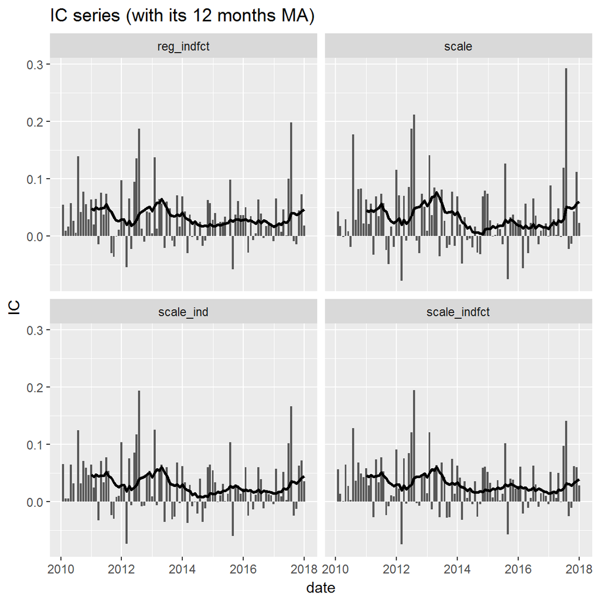

```r
MF.chart.IC(mTSFR = mtsfr,facet_by = 'fname')
```

不同refine方式下因子分组多空收益图

```
## The guessed factorNames are: scale,scale_ind,scale_indfct,reg_indfct.
```

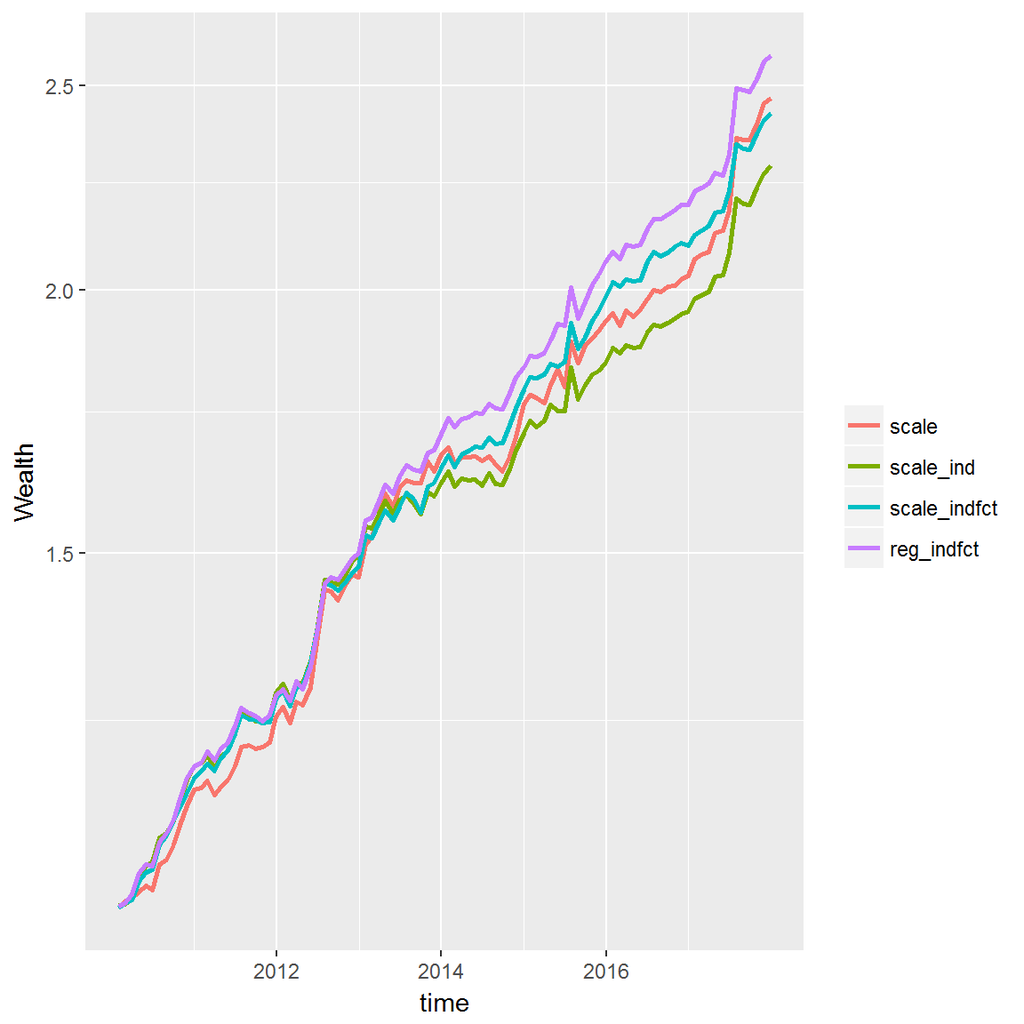

```r
MF.chart.Ngroup.spread(mTSFR = mtsfr, N = 5)
```

不同refine方式下因子分组多空相对收益图

```
## The guessed factorNames are: scale,scale_ind,scale_indfct,reg_indfct.
```

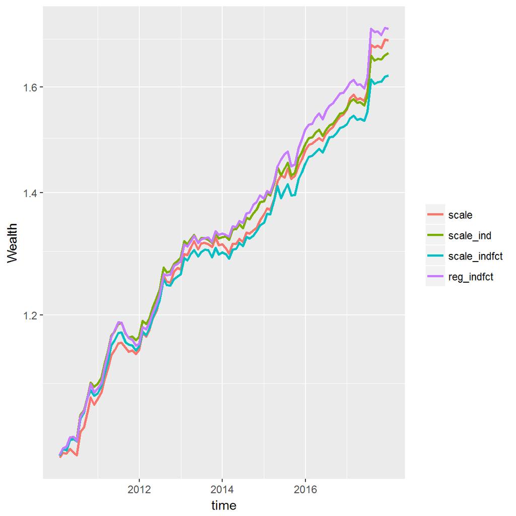

```r
MF.chart.Ngroup.spread(mTSFR = mtsfr, N = 5,rtn_type = "long-univ")
```

不同refine方式下因子IC和分组收益统计表

```r
table_ <- MC.table.ICandNgroup(mTSF2TSFs(mtsfr), N = 5)
```

```
## The guessed factorNames are: scale,scale_ind,scale_indfct,reg_indfct.
```

```r
table_ <- table_[,tablenames]
kable(table_,digits = 2)
```

|  | IC_mean | IC_IR | IC_hitRatio | Annualized Return | Annualized Sharpe(Rf=0%) | Worst Drawdown | Beta | Size |
| --- | --- | --- | --- | --- | --- | --- | --- | --- |
| scale | 0.03 | 0.56 | 0.69 | 0.12 | 2.09 | 0.03 | -0.03 | 25.19 |
| scale_ind | 0.03 | 0.65 | 0.72 | 0.11 | 2.17 | 0.03 | -0.04 | 4.72 |
| scale_indfct | 0.03 | 0.72 | 0.76 | 0.12 | 2.55 | 0.03 | -0.03 | 0.97 |
| reg_indfct | 0.03 | 0.74 | 0.76 | 0.13 | 2.54 | 0.03 | -0.01 | -7.46 |

```r
table_ <- data.frame(factorName=fname_,refinePar=rownames(table_),table_,row.names = NULL,stringsAsFactors = FALSE)
tablestats <- rbind(tablestats,table_)
```

## 5、因子G_OR_longterm

```r
fname_ <- fnames[5]
tsfr <- tsfrs_raw[[fname_]]
mtsfr <- factor_refine_MF(tsfr,refinePars)
```

```
## Function getTSF: getting the factorscore ....
## Function getTSF: getting the factorscore ....
```

```r
mtsfrrefine <- rbind(mtsfrrefine,data.frame(mtsfr,fname=fname_))
```

因子NA比例

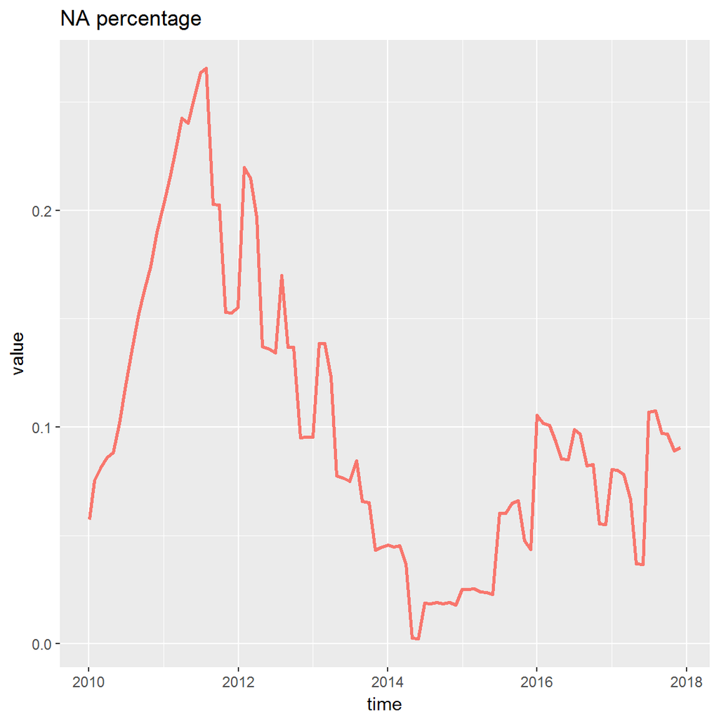

```r
chart.Fct_NA(tsfr)
```

因子原始得分直方图

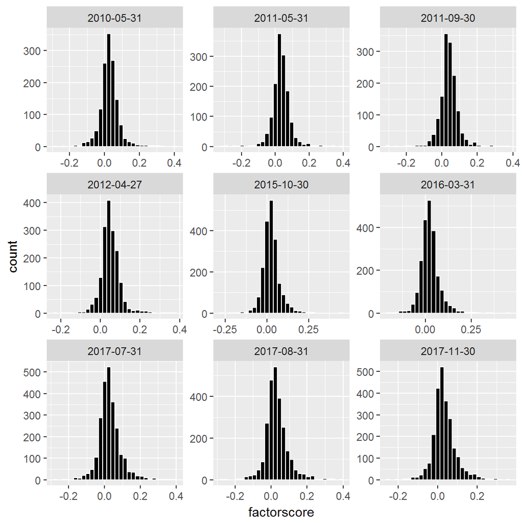

```r
chart.Fct_hist(tsfr,9)
```

不同refine方式下因子得分分布直方图

```
## The guessed factorNames are: scale,scale_ind,scale_indfct,reg_indfct.
```

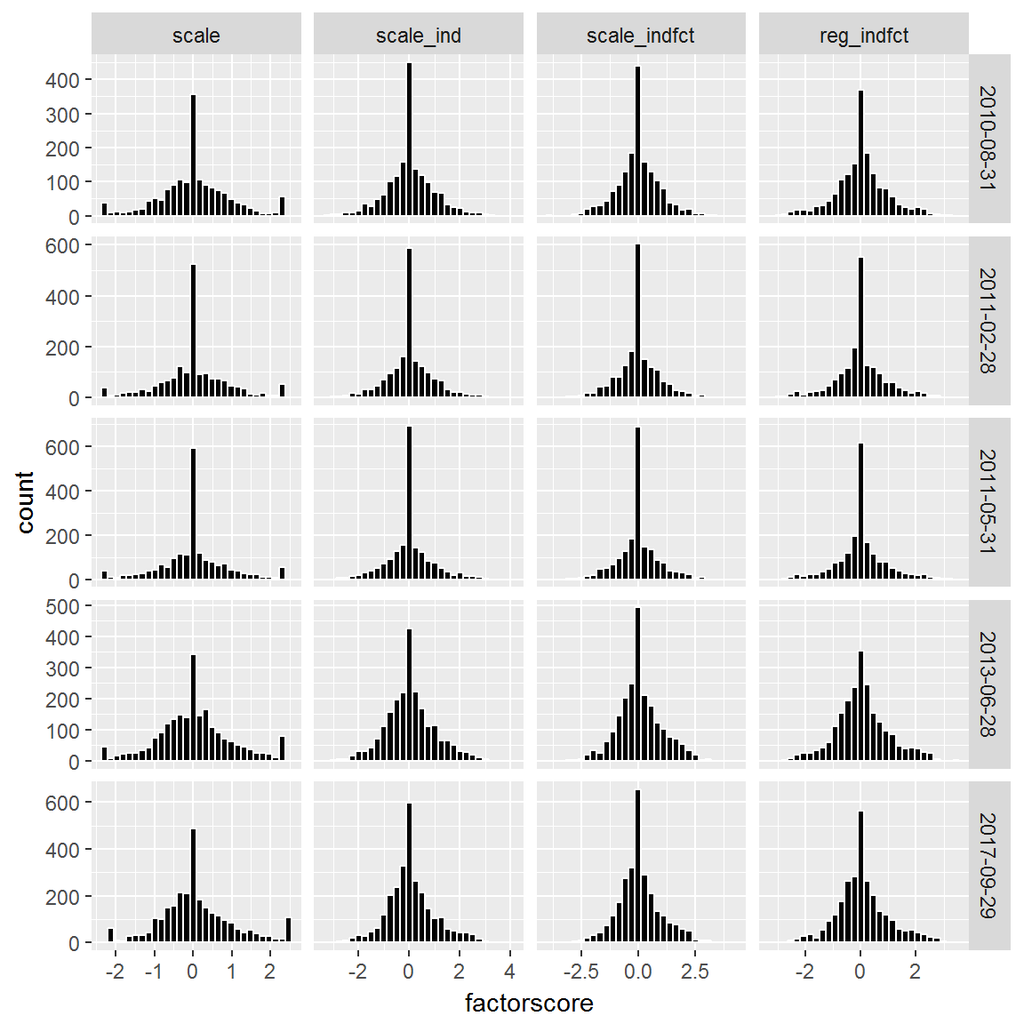

```r
MF.chart.Fct_hist(mtsfr,5)
```

不同refine方式下因子得分统计表

```r
kable(MF.table.Fct_descr(mtsfr,5),digits = 2)
```

```
## The guessed factorNames are: scale,scale_ind,scale_indfct,reg_indfct.
```

| date | fname | Obs | NAs | min | max | mean | median | sd | skewness | kurtosis |
| --- | --- | --- | --- | --- | --- | --- | --- | --- | --- | --- |
| 2010-04-30 | scale | 1543 | 0 | -2.24 | 2.32 | 0.02 | 0.00 | 0.95 | 0.06 | 0.49 |
| 2010-04-30 | scale_ind | 1543 | 0 | -2.99 | 3.52 | 0.03 | 0.00 | 0.95 | 0.03 | 0.83 |
| 2010-04-30 | scale_indfct | 1543 | 0 | -3.84 | 3.52 | 0.00 | 0.00 | 0.95 | -0.04 | 0.91 |
| 2010-04-30 | reg_indfct | 1543 | 0 | -2.91 | 3.03 | 0.00 | -0.01 | 0.96 | 0.01 | 0.74 |
| 2012-03-30 | scale | 1987 | 0 | -2.31 | 2.45 | 0.06 | 0.00 | 0.90 | 0.19 | 1.01 |
| 2012-03-30 | scale_ind | 1987 | 0 | -2.91 | 3.13 | 0.04 | 0.00 | 0.89 | 0.20 | 1.11 |
| 2012-03-30 | scale_indfct | 1987 | 0 | -3.04 | 3.26 | 0.05 | 0.00 | 0.89 | 0.21 | 1.15 |
| 2012-03-30 | reg_indfct | 1987 | 0 | -2.76 | 3.21 | 0.05 | -0.01 | 0.90 | 0.25 | 1.24 |
| 2013-06-28 | scale | 2217 | 0 | -2.30 | 2.32 | 0.04 | 0.00 | 0.96 | 0.15 | 0.40 |
| 2013-06-28 | scale_ind | 2217 | 0 | -2.94 | 3.10 | 0.05 | 0.00 | 0.96 | 0.21 | 0.54 |
| 2013-06-28 | scale_indfct | 2217 | 0 | -3.36 | 3.44 | 0.07 | 0.00 | 0.96 | 0.15 | 0.54 |
| 2013-06-28 | reg_indfct | 2217 | 0 | -2.78 | 3.55 | 0.06 | 0.01 | 0.96 | 0.24 | 0.58 |
| 2013-09-30 | scale | 2252 | 0 | -2.31 | 2.36 | 0.04 | 0.00 | 0.97 | 0.20 | 0.41 |
| 2013-09-30 | scale_ind | 2252 | 0 | -3.15 | 3.19 | 0.06 | 0.00 | 0.97 | 0.25 | 0.54 |
| 2013-09-30 | scale_indfct | 2252 | 0 | -3.26 | 3.13 | 0.07 | 0.00 | 0.96 | 0.21 | 0.39 |
| 2013-09-30 | reg_indfct | 2252 | 0 | -2.77 | 3.51 | 0.07 | 0.01 | 0.97 | 0.28 | 0.57 |
| 2016-10-31 | scale | 2529 | 0 | -2.23 | 2.35 | 0.08 | 0.00 | 0.97 | 0.32 | 0.28 |
| 2016-10-31 | scale_ind | 2529 | 0 | -3.00 | 3.77 | 0.08 | 0.00 | 0.97 | 0.43 | 0.95 |
| 2016-10-31 | scale_indfct | 2529 | 0 | -3.71 | 4.09 | 0.06 | 0.00 | 0.97 | 0.36 | 1.05 |
| 2016-10-31 | reg_indfct | 2529 | 0 | -3.45 | 3.87 | 0.06 | 0.00 | 0.97 | 0.31 | 0.79 |

不同refine方式下因子IC图

```
## The guessed factorNames are: scale,scale_ind,scale_indfct,reg_indfct.
```

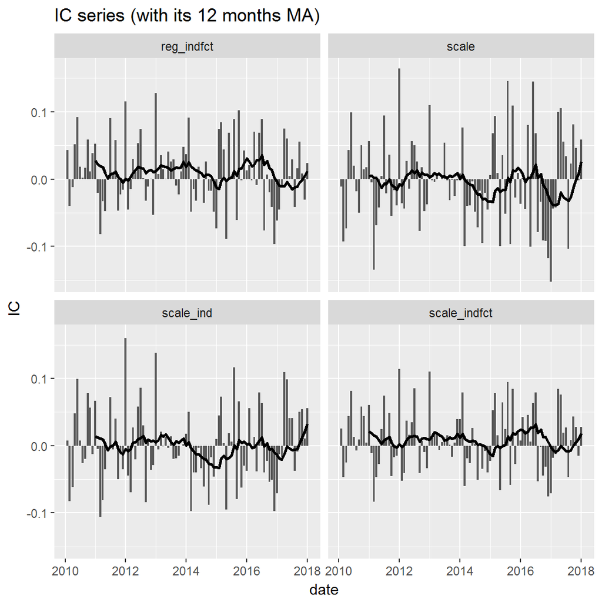

```r
MF.chart.IC(mTSFR = mtsfr,facet_by = 'fname')
```

不同refine方式下因子分组多空收益图

```
## The guessed factorNames are: scale,scale_ind,scale_indfct,reg_indfct.
```

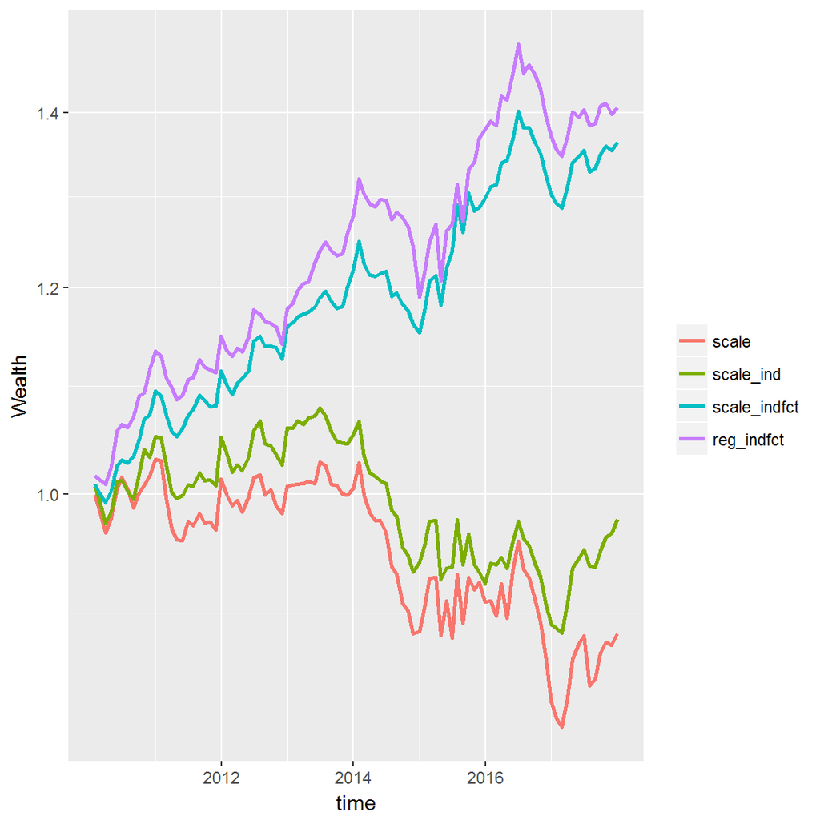

```r
MF.chart.Ngroup.spread(mTSFR = mtsfr, N = 5)
```

不同refine方式下因子分组多空相对收益图

```
## The guessed factorNames are: scale,scale_ind,scale_indfct,reg_indfct.
```

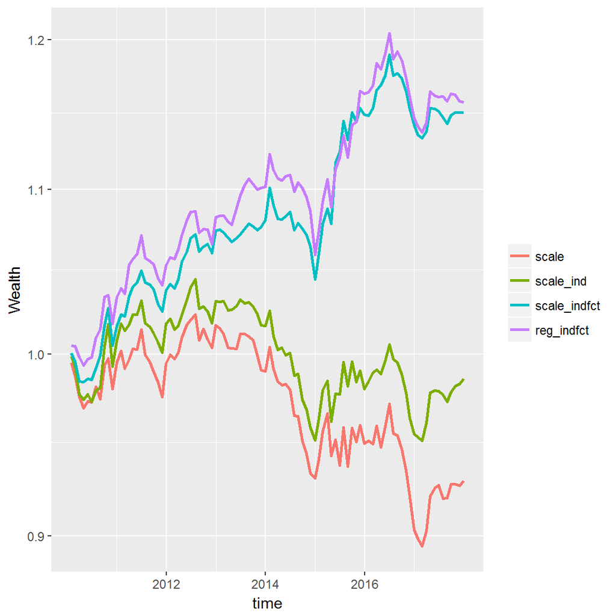

```r
MF.chart.Ngroup.spread(mTSFR = mtsfr, N = 5,rtn_type = "long-univ")
```

不同refine方式下因子IC和分组收益统计表

```r
table_ <- MC.table.ICandNgroup(mTSF2TSFs(mtsfr), N = 5)
```

```
## The guessed factorNames are: scale,scale_ind,scale_indfct,reg_indfct.
```

```r
table_ <- table_[,tablenames]
kable(table_,digits = 2)
```

|  | IC_mean | IC_IR | IC_hitRatio | Annualized Return | Annualized Sharpe(Rf=0%) | Worst Drawdown | Beta | Size |
| --- | --- | --- | --- | --- | --- | --- | --- | --- |
| scale | 0.00 | -0.06 | 0.44 | -0.02 | -0.22 | 0.21 | -0.03 | 60.97 |
| scale_ind | 0.00 | 0.00 | 0.45 | 0.00 | -0.05 | 0.18 | -0.06 | -46.02 |
| scale_indfct | 0.01 | 0.20 | 0.59 | 0.04 | 0.81 | 0.08 | -0.02 | -77.81 |
| reg_indfct | 0.01 | 0.22 | 0.59 | 0.04 | 0.74 | 0.10 | 0.01 | -179.79 |

```r
table_ <- data.frame(factorName=fname_,refinePar=rownames(table_),table_,row.names = NULL,stringsAsFactors = FALSE)
tablestats <- rbind(tablestats,table_)
```

## 6、因子F_NP_chg

```r
fname_ <- fnames[6]
tsfr <- tsfrs_raw[[fname_]]
mtsfr <- factor_refine_MF(tsfr,refinePars)
```

```
## Function getTSF: getting the factorscore ....
## Function getTSF: getting the factorscore ....
```

```r
mtsfrrefine <- rbind(mtsfrrefine,data.frame(mtsfr,fname=fname_))
```

因子NA比例

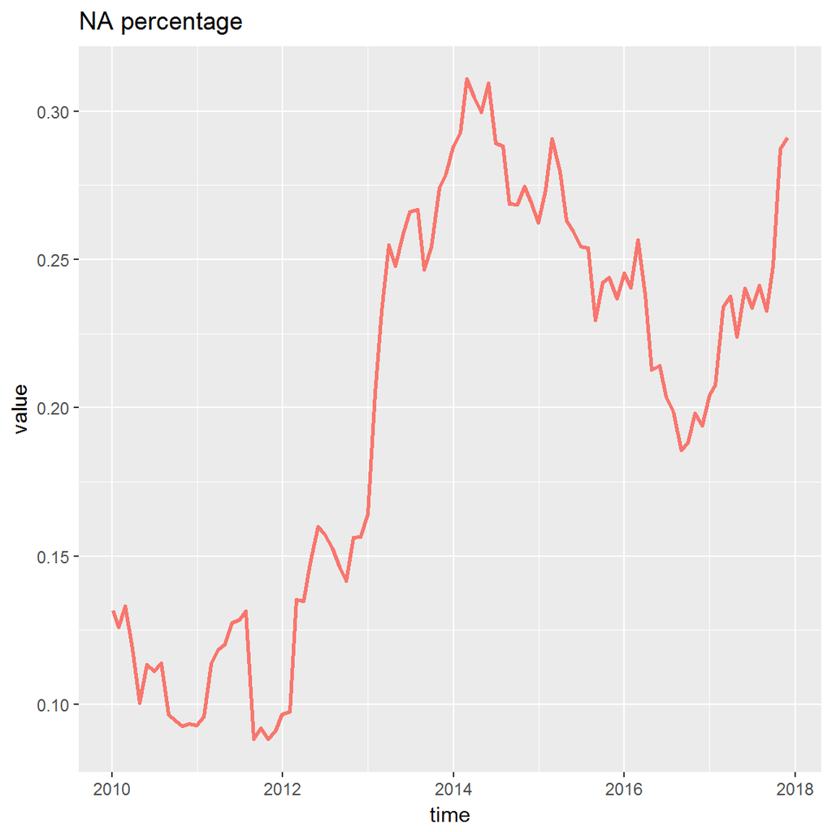

```r
chart.Fct_NA(tsfr)
```

因子原始得分直方图

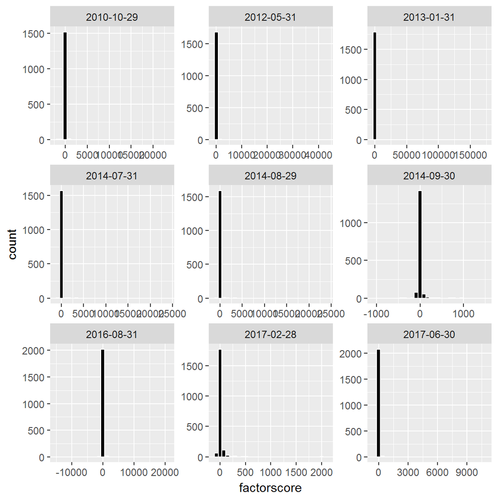

```r
chart.Fct_hist(tsfr,9)
```

不同refine方式下因子得分分布直方图

```
## The guessed factorNames are: scale,scale_ind,scale_indfct,reg_indfct.
```

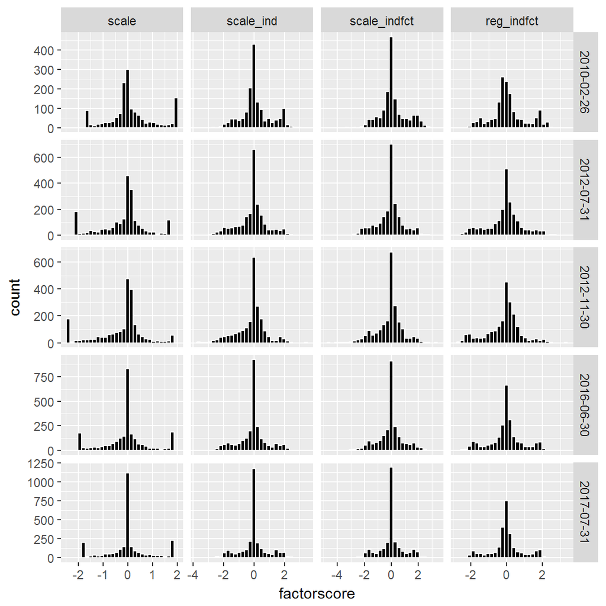

```r
MF.chart.Fct_hist(mtsfr,5)
```

不同refine方式下因子得分统计表

```r
kable(MF.table.Fct_descr(mtsfr,5),digits = 2)
```

```
## The guessed factorNames are: scale,scale_ind,scale_indfct,reg_indfct.
```